# R Notebook

### Exploring Training Results

As mentioned in the first R tutorial, most model objects in `R` are stored as specialized lists.

The `lm_fit` object is list that contains all of the information about how our model was trained as well as the detailed results. Let’s use the `names()` function to print the named objects that are stored within `lm_fit`.

The important objects are `fit` and `preproc`. These contain the trained model and preprocessing steps (if any are used), respectively.

```r
names(lm_fit)
```

```
## [1] "lvl"     "spec"    "fit"     "preproc" "elapsed"
```

To print a summary of our model, we can extract `fit` from `lm_fit` and pass it to the `summary()` function. We can explore the estimated coefficients, F-statistics, p-values, residual standard error (also known as RMSE) and R2 value.

```r
summary(lm_fit$fit)
```

```
##
## Call:
## stats::lm(formula = price ~ ., data = data)
##
## Residuals:
##      Min       1Q   Median       3Q      Max
## -1305711   -97697    -8809    77631  4267652
##
## Coefficients: (1 not defined because of singularities)
##                 Estimate Std. Error t value Pr(>|t|)
## (Intercept)   -6.382e+07  8.924e+06  -7.152 9.02e-13 ***
## id            -1.276e-06  6.230e-07  -2.049   0.0405 *
## date           3.579e+00  4.010e-01   8.924  < 2e-16 ***
## bedrooms      -3.336e+04  2.424e+03 -13.765  < 2e-16 ***
## bathrooms      4.798e+04  4.253e+03  11.281  < 2e-16 ***
## sqftliving     1.492e+02  5.651e+00  26.400  < 2e-16 ***
## sqftlot       -8.846e-02  4.618e-02  -1.916   0.0554 .
## floors         2.032e+02  4.685e+03   0.043   0.9654
## waterfront     5.673e+05  2.282e+04  24.865  < 2e-16 ***
## view           5.463e+04  2.738e+03  19.952  < 2e-16 ***
## condition      2.872e+04  3.070e+03   9.356  < 2e-16 ***
## grade          1.027e+05  2.698e+03  38.065  < 2e-16 ***
## sqft_above     3.752e+01  5.630e+00   6.663 2.78e-11 ***
## sqft_basement         NA         NA      NA       NA
## yr_built      -2.717e+03  9.456e+01 -28.739  < 2e-16 ***
## yr_renovated   2.051e+01  4.757e+00   4.312 1.63e-05 ***
## zipcode       -5.977e+02  4.274e+01 -13.984  < 2e-16 ***
## lat            6.087e+05  1.395e+04  43.633  < 2e-16 ***
## long          -2.130e+05  1.686e+04 -12.640  < 2e-16 ***
## ---
## Signif. codes:  0 '***' 0.001 '**' 0.01 '*' 0.05 '.' 0.1 ' ' 1
##
## Residual standard error: 202400 on 12949 degrees of freedom
## Multiple R-squared:  0.7017, Adjusted R-squared:  0.7013
## F-statistic:  1792 on 17 and 12949 DF,  p-value: < 2.2e-16
```

We can use the `plot()` function to obtain diagnostic plots for our trained regression model. Again, we must first extract the `fit` object from `lm_fit` and then pass it into `plot()`. These plots provide a check for the main assumptions of the linear regression model.

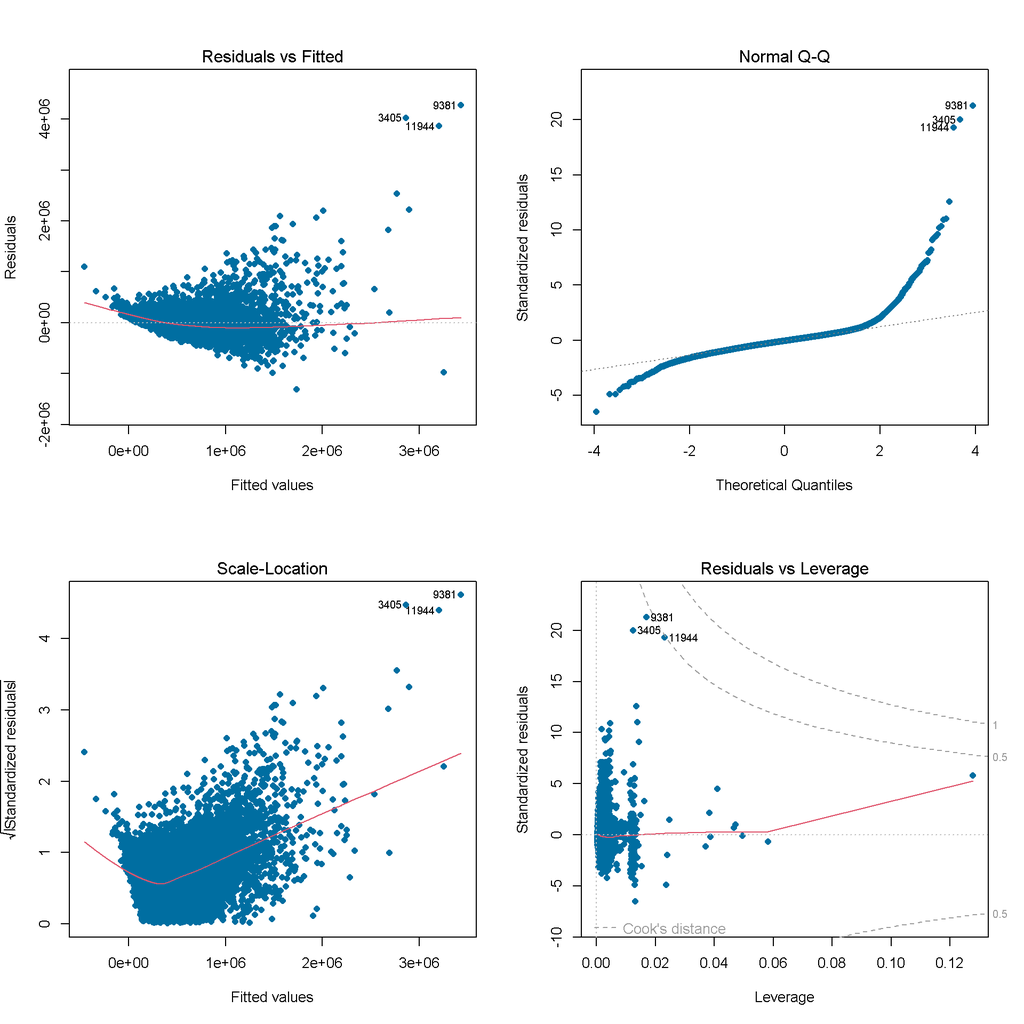

```r
par(mfrow=c(2,2)) # plot all 4 plots in one

plot(lm_fit$fit,
     pch = 16,    # optional parameters to make points blue
     col = '#006EA1')
```